# Praktikum 6 Anreg

# Library

```r
library(readxl) # untuk membaca data
library(GGally) # untuk menghasilkan matriks hubungan antarpeubah
library(corrplot) # untuk menghasilkan matriks korelasi
library(dplyr) # untuk manipulasi data
library(car) # untuk memeriksa multikolinearitas
library(stargazer) # untuk menampilkan hasil perbandingan regresi
library(lmtest) # untuk uji kehomogenan ragam sisaan dan saling bebas
library(olsrr) # untuk pemeriksaan amatan tidak biasa
```

Data

```r
dt <- read_xlsx("C:\\Users\\Lenovo\\Downloads\\Data6 (1).xlsx")
dt # menampilkan data
```

[output not shown]

```r
str(dt) # menampilkan tipe data setiap peubah
```

```
## tibble [22 × 7] (S3: tbl_df/tbl/data.frame)
##  $ Wilayah: chr [1:22] "Sumba Barat" "Sumba Timur" "Kupang" "Timor Tengah Selatan" ...
##  $ PPM    : num [1:22] 27.2 28.1 21.8 25.2 21.9 ...
##  $ IPM    : num [1:22] 65.2 67 65.8 63.6 65.2 ...
##  $ RLS    : num [1:22] 6.92 7.57 7.42 6.97 8.16 7.39 8.45 8.26 8.04 6.98 ...
##  $ PBH    : num [1:22] 11.9 5.87 6.17 7.71 3.98 6.34 1.75 3.95 3.69 5.02 ...
##  $ PDRB   : num [1:22] 10199 16617 13793 10953 11511 ...
##  $ PKB    : num [1:22] 82.8 68.8 72.8 83.8 77.7 ...
```

```r
summary(dt) # menampilkan ringkasan data
```

```
##    Wilayah               PPM             IPM             RLS
##  Length:22          Min.   : 8.61   Min.   :58.89   Min.   : 6.380
##  Class :character   1st Qu.:14.33   1st Qu.:63.62   1st Qu.: 7.032
##  Mode  :character   Median :21.82   Median :65.50   Median : 7.665
##                     Mean   :20.64   Mean   :65.71   Mean   : 7.796
##                     3rd Qu.:26.58   3rd Qu.:66.77   3rd Qu.: 8.155
##                     Max.   :31.78   Max.   :80.62   Max.   :11.620
##       PBH              PDRB            PKB
##  Min.   : 0.760   Min.   : 7706   Min.   : 4.29
##  1st Qu.: 1.885   1st Qu.: 9064   1st Qu.:68.49
##  Median : 4.020   Median :10797   Median :75.14
##  Mean   : 5.195   Mean   :12471   Mean   :72.22
##  3rd Qu.: 7.367   3rd Qu.:13914   3rd Qu.:82.31
##  Max.   :13.390   Max.   :38169   Max.   :93.27
```

```r
dt <- select(dt, -Wilayah)
```

# Eksplorasi Data

## Peubah Respon

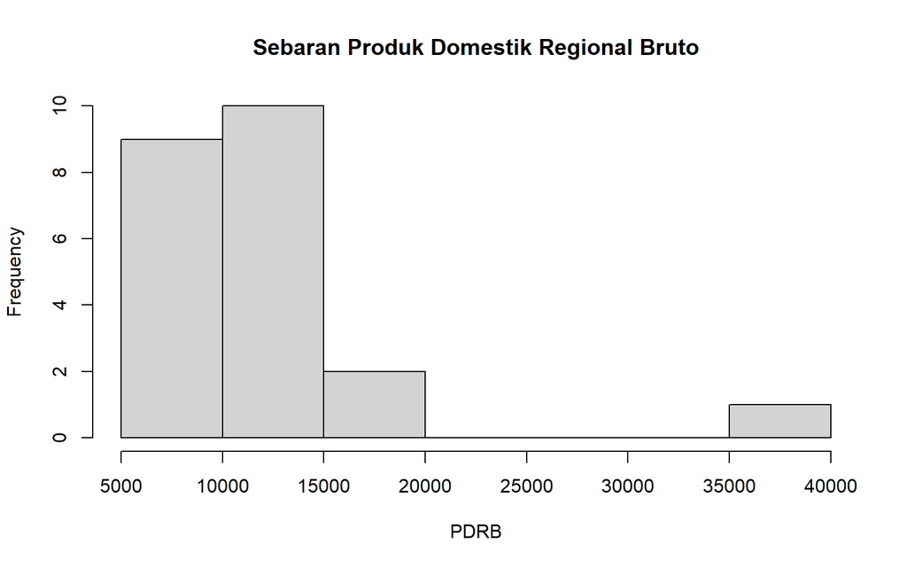

```r
hist(dt$PDRB,
     main = "Sebaran Produk Domestik Regional Bruto",
     xlab = "PDRB")
```

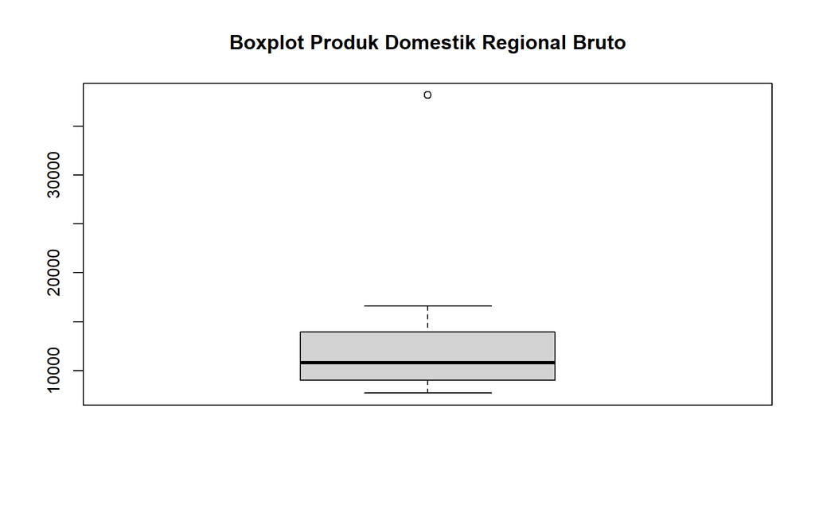

```r
boxplot(dt$PDRB,
        main = "Boxplot Produk Domestik Regional Bruto")
```

## Peubah Pennjelas vs Peubah Respon

### IPM

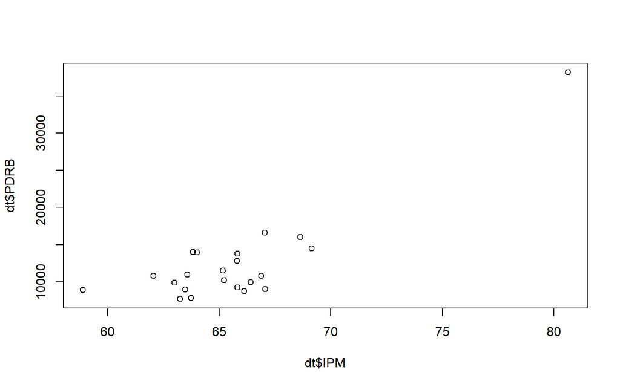

```r
plot(dt$IPM, dt$PDRB)
```

Hubungan antara IPM dan PDRB cenderung positif. Daerah dengan kualitas pembangunan manusia yang lebih baik umumnya memiliki aktivitas ekonomi yang lebih tinggi.

### RLS

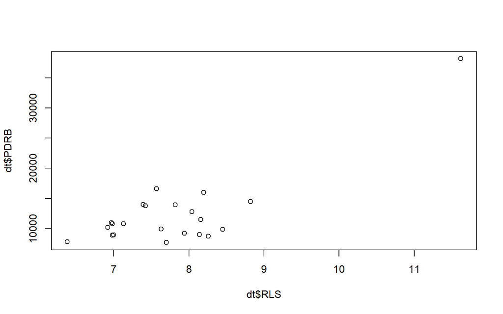

```r
plot(dt$RLS, dt$PDRB)
```

Nilai rata-rata lama sekolah menunjukkan kecenderungan hubungan positif terhadap PDRB meskipun terdapat beberapa pengamatan yang cukup jauh dari pola umum.

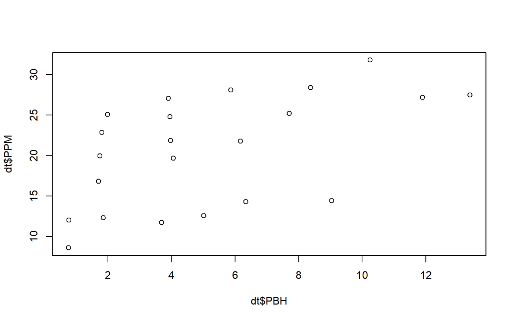

```r
plot(dt$PBH, dt$PPM)
```

Hubungan linearitas tampak antara peubah PBH dan PPM, tidak ada amatan dengan nilai yang jauh dari amatan lainnya

### PBH

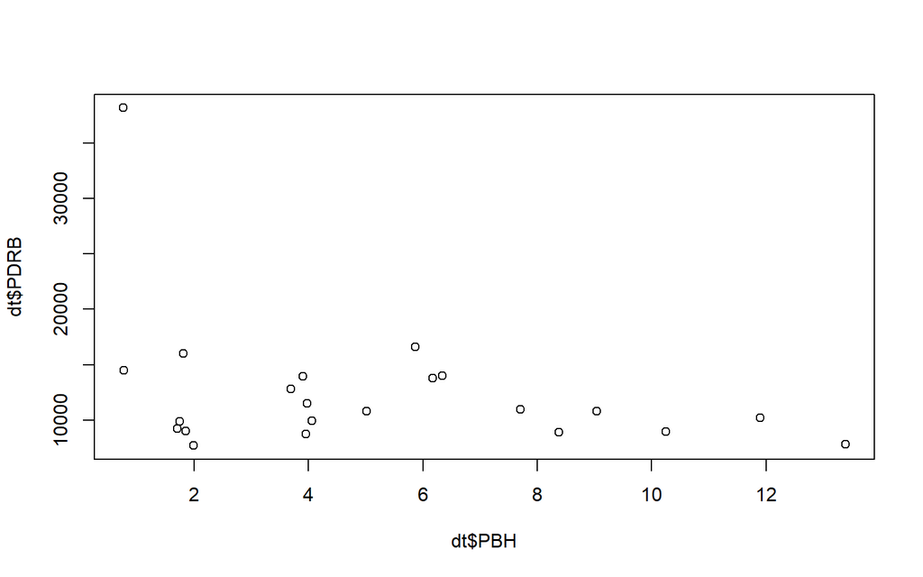

```r
plot(dt$PBH, dt$PDRB)
```

Persentase buta huruf memiliki kecenderungan hubungan negatif terhadap PDRB. Semakin tinggi persentase buta huruf, nilai PDRB cenderung menurun.

# PKB

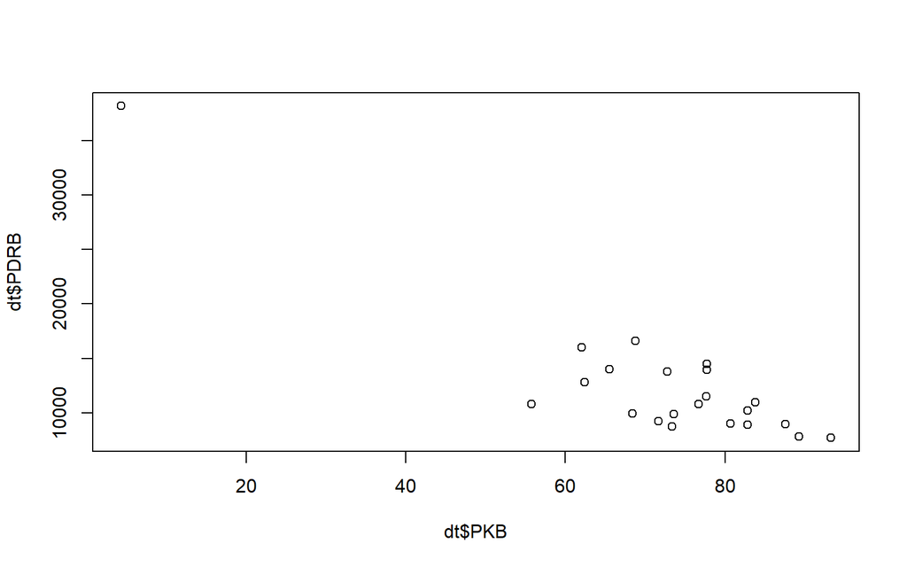

```r
plot(dt$PKB, dt$PDRB)
```

Penggunaan kayu bakar menunjukkan hubungan negatif terhadap PDRB. Daerah dengan persentase penggunaan kayu bakar yang tinggi cenderung memiliki tingkat aktivitas ekonomi yang lebih rendah.

## Korelasi

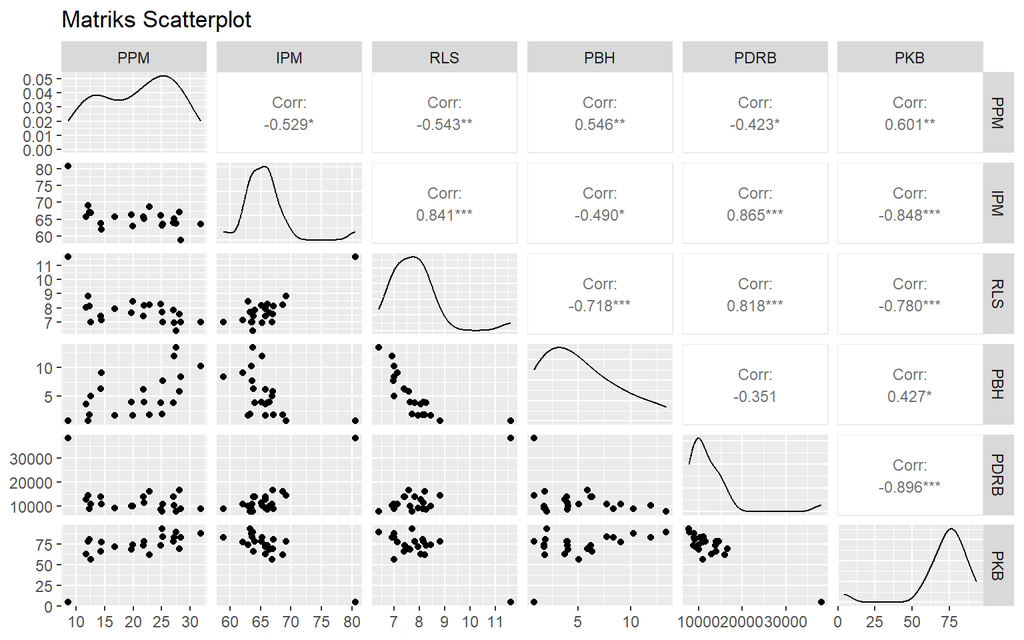

```r
ggpairs(dt,
        upper=list(continuous=wrap("cor",size=3)),
        title="Matriks Scatterplot")
```

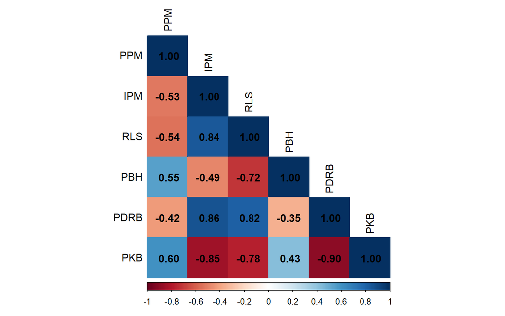

```r
cor_matrix <- cor(dt)

corrplot(cor_matrix,
         method="color",
         type="lower",
         addCoef.col="black",
         tl.col="black")
```

Berdasarkan matriks korelasi terlihat bahwa PDRB mempunyai hubungan positif dengan IPM dan RLS, sedangkan hubungan negatif terlihat dengan PPM, PBH, dan PKB. Selain itu terdapat beberapa pasangan peubah penjelas yang memiliki korelasi cukup tinggi sehingga perlu dilakukan pemeriksaan multikolinearitas sebelum membangun model regresi.

# Pemodelan

```r
model1 <- lm(PDRB ~ PPM + IPM + RLS + PBH + PKB,
             data = dt)

summary(model1)
```

```
##
## Call:
## lm(formula = PDRB ~ PPM + IPM + RLS + PBH + PKB, data = dt)
##
## Residuals:
##     Min      1Q  Median      3Q     Max
## -4926.6 -1202.8    18.1  1775.0  2745.7
##
## Coefficients:
##              Estimate Std. Error t value Pr(>|t|)
## (Intercept) -19893.52   19058.54  -1.044  0.31209
## PPM            120.84     100.45   1.203  0.24651
## IPM            280.49     275.87   1.017  0.32441
## RLS           2960.68    1197.95   2.471  0.02507 *
## PBH            438.52     226.03   1.940  0.07020 .
## PKB           -192.76      58.62  -3.288  0.00463 **
## ---
## Signif. codes:  0 '***' 0.001 '**' 0.01 '*' 0.05 '.' 0.1 ' ' 1
##
## Residual standard error: 2240 on 16 degrees of freedom
## Multiple R-squared:  0.9037, Adjusted R-squared:  0.8736
## F-statistic: 30.02 on 5 and 16 DF,  p-value: 1.371e-07
```

Berdasarkan hasil pemodelan regresi, diperoleh bahwa model secara keseluruhan signifikan pada taraf nyata 5%, yang ditunjukkan oleh nilai p-value uji F sebesar 1,371 × 10⁻⁷ (< 0,05). Hal ini menunjukkan bahwa terdapat paling sedikit satu peubah penjelas yang berpengaruh terhadap Produk Domestik Regional Bruto (PDRB). Secara parsial, peubah Rata-rata Lama Sekolah (RLS) dan Persentase Penduduk yang Menggunakan Kayu Bakar (PKB) berpengaruh signifikan terhadap PDRB karena memiliki p-value masing-masing sebesar 0,0251 dan 0,0046. Sementara itu, peubah PPM, IPM, dan PBH belum menunjukkan pengaruh yang signifikan pada taraf nyata 5%. Nilai Adjusted R² sebesar 0,8736 menunjukkan bahwa sekitar 87,36% variasi PDRB dapat dijelaskan oleh peubah-peubah dalam model, sedangkan sisanya dipengaruhi oleh faktor lain yang tidak dimasukkan ke dalam model.

# Pemeriksaan Multikolinearitas

## Perubahan Peubah

```r
mod1 <- lm(PDRB ~ PPM, data=dt)

mod2 <- lm(PDRB ~ PPM + IPM, data=dt)

mod3 <- lm(PDRB ~ PPM + IPM + RLS, data=dt)

mod4 <- lm(PDRB ~ PPM + IPM + RLS + PBH,
           data=dt)

mod5 <- lm(PDRB ~ PPM + IPM + RLS + PBH + PKB,
           data=dt)
```

## Perubahan Banyak Data

```r
mod5_1 <- lm(PDRB ~ PPM + IPM + RLS + PBH + PKB,
             data = dt[1:15,])

stargazer(summary(mod5)$coefficients,
          summary(mod5_1)$coefficients,
          type = "text",
          font.size = "small")
```

```
##
## ======================================================
##              Estimate   Std. Error t value Pr(> | t| )
## ------------------------------------------------------
## (Intercept) -19,893.520 19,058.540 -1.044     0.312
## PPM           120.838    100.455    1.203     0.247
## IPM           280.492    275.875    1.017     0.324
## RLS          2,960.682  1,197.948   2.471     0.025
## PBH           438.521    226.028    1.940     0.070
## PKB          -192.758     58.619   -3.288     0.005
## ------------------------------------------------------
##
## ======================================================
##              Estimate   Std. Error t value Pr(> | t| )
## ------------------------------------------------------
## (Intercept) -23,651.980 35,802.020 -0.661     0.525
## PPM           116.279    161.468    0.720     0.490
## IPM           476.251    482.143    0.988     0.349
## RLS          1,076.102  2,898.245   0.371     0.719
## PBH           179.081    609.654    0.294     0.776
## PKB           -98.054    135.533   -0.723     0.488
## ------------------------------------------------------
```

Dugaan koefisien pada beberapa peubah mengalami perubahan ketika jumlah amatan dikurangi. Hal ini menunjukkan bahwa model cukup sensitif terhadap perubahan data sehingga diperlukan pemeriksaan multikolinearitas dan diagnostik model lebih lanjut.

## Akar Ciri

```r
## Akar Ciri

x <- dt %>% select(PPM, IPM, RLS, PBH, PKB)

r <- cor(x)

(ev <- eigen(r)$values)
```

```
## [1] 3.55493175 0.68433600 0.52534882 0.13694140 0.09844204
```

```r
# Simultan
if ((max(ev) / min(ev)) <= 100) {
  cat("Tidak ada multikolinearitas\n")
} else if ((max(ev) / min(ev)) > 100 & (max(ev) / min(ev)) <= 1000) {
  cat("Ada multikolinearitas yang lemah\n")
} else {
  cat("Ada multikolinearitas yang kuat\n")
}
```

```
## Tidak ada multikolinearitas
```

```r
# Parsial
if (all((max(ev) / ev) <= 1000)) {
  cat("Tidak ada multikolinearitas\n")
} else {
  cat("Ada multikolinearitas pada peubah penjelas ke:", which((max(ev) / ev) > 1000), "\n")
}
```

```
## Tidak ada multikolinearitas
```

## Nilai VIF

```r
vif(model1)
```

```
##      PPM      IPM      RLS      PBH      PKB
## 1.932968 5.189694 6.599042 2.812009 4.573010
```

# Pemodelan Penyisihan Peubah

```r
model2 <- lm(PPM ~ IPM + PBH + PDRB + PKB, data = dt)
summary(model2)
```

```
##
## Call:
## lm(formula = PPM ~ IPM + PBH + PDRB + PKB, data = dt)
##
## Residuals:
##     Min      1Q  Median      3Q     Max
## -9.7905 -0.9878  0.5303  2.8854  7.0689
##
## Coefficients:
##               Estimate Std. Error t value Pr(>|t|)
## (Intercept)  2.4478478 44.4581508   0.055   0.9567
## IPM         -0.2701044  0.6267602  -0.431   0.6719
## PBH          0.5673230  0.3672478   1.545   0.1408
## PDRB         0.0006738  0.0004638   1.453   0.1645
## PKB          0.3404346  0.1533585   2.220   0.0403 *
## ---
## Signif. codes:  0 '***' 0.001 '**' 0.01 '*' 0.05 '.' 0.1 ' ' 1
##
## Residual standard error: 5.179 on 17 degrees of freedom
## Multiple R-squared:  0.5255, Adjusted R-squared:  0.4139
## F-statistic: 4.707 on 4 and 17 DF,  p-value: 0.009674
```

Persamaan yang terbentuk adalah

$$\hat{PPM}=2.4478−0.2701IPM+0.5673PBH+0.0007PDRB+0.3404PKB$$

Pada ringkasan model ini dapat dilihat bahwa secara simultan minimal ada satu peubah penjelas yang berpengaruh signifikan terhadap PPM. Hal tersebut selaras karena terdapat dugaan parameter yang signifikan pada taraf nyata 5%, yaitu peubah PKB. Peubah PDRB mengalami perubahan tanda dalam dugaan parameternya jika dibandingkan dengan arah korelasi, sehingga mengindikasi ada permasalahan dalam model.

## Nilai VIF

```r
vif(model2)
```

```
##      IPM      PBH     PDRB      PKB
## 5.010355 1.388535 6.682993 5.854468
```

Model hasil reduksi peubah menunjukkan bahwa nilai VIF < 10 sehingga dinyatakan tidak terjadi multikolinearitas. Namun masih ada peubah yang mengalami perubahan tanda arah korelasi. Artinya ada permasalahan lain yang mungkin belum tertangani, perlu dilakuan uji asumsi dan pemeriksaan pencilan, leverage, dan amatan berpengaruh

# Pengujian Asumsi

## Eksplorasi Grafik

### Plot Sisaan vs Y duga

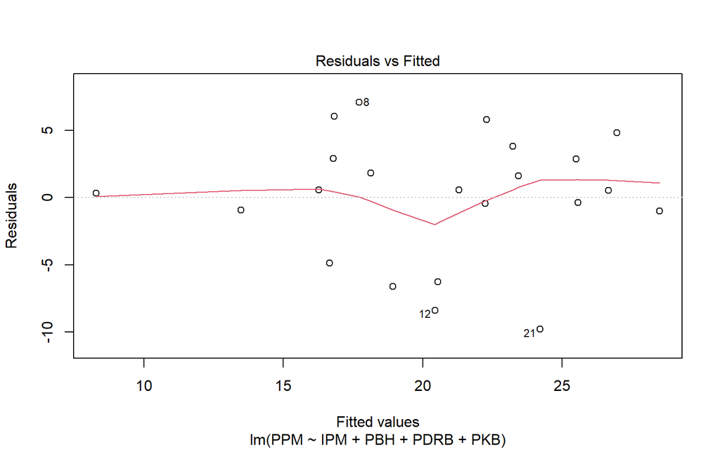

```r
plot(model2,1)
```

Titik-titik residual menyebar di sekitar garis horizontal nol tanpa pola tertentu. Meskipun demikian masih terlihat sedikit perubahan lebar sebaran residual sehingga asumsi homogenitas ragam perlu dipastikan melalui pengujian formal.

### Plot Sisaan vs Urutan

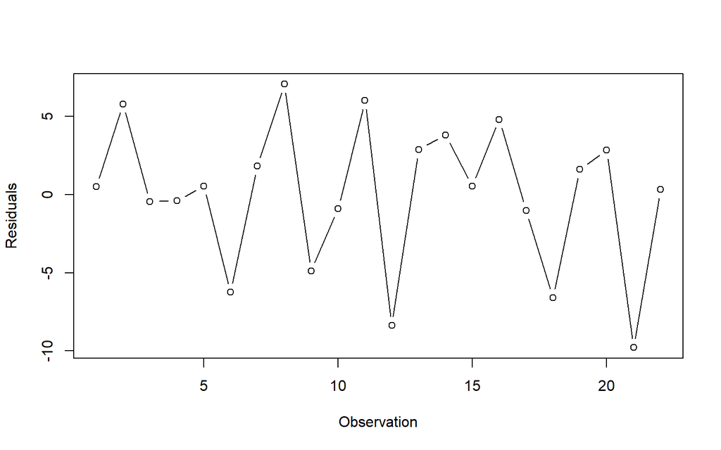

```r
plot(
  x = seq_along(model2$residuals),
  y = model2$residuals,
  type = "b",
  xlab = "Observation",
  ylab = "Residuals"
)
```

Sebaran residual berdasarkan urutan pengamatan tidak membentuk pola yang jelas sehingga tidak terdapat indikasi ketergantungan antar residual.

### QQ plot

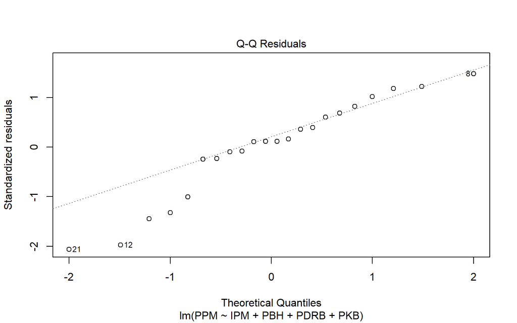

```r
plot(model2,2)
```

Sebagian besar titik berada di sekitar garis diagonal meskipun terdapat sedikit penyimpangan pada bagian ekor. Secara visual asumsi normalitas residual masih cukup terpenuhi.

## Uji Formal

### Nilai harapan sisaan sama dengan nol

```r
t.test(model2$residuals,mu = 0,conf.level = 0.95)
```

```
##
##  One Sample t-test
##
## data:  model2$residuals
## t = -1.4737e-16, df = 21, p-value = 1
## alternative hypothesis: true mean is not equal to 0
## 95 percent confidence interval:
##  -2.065887  2.065887
## sample estimates:
##     mean of x
## -1.463981e-16
```

Karena nilai p-value lebih besar dari 0,05 maka rata-rata residual tidak berbeda nyata dari nol. Dengan demikian asumsi nilai harapan residual sama dengan nol dapat diterima.

### Ragam sisaan homogen

```r
bptest(model2)
```

```
##
##  studentized Breusch-Pagan test
##
## data:  model2
## BP = 0.58204, df = 4, p-value = 0.965
```

Nilai p-value yang lebih besar dari 0,05 menunjukkan bahwa varians residual bersifat homogen sehingga tidak terdapat indikasi heteroskedastisitas.

### Sisaan saling bebas

```r
dwtest(model2)
```

```
##
##  Durbin-Watson test
##
## data:  model2
## DW = 2.5773, p-value = 0.8634
## alternative hypothesis: true autocorrelation is greater than 0
```

Berdasarkan uji Durbin-Watson diperoleh p-value lebih besar dari 0,05 sehingga residual dapat dianggap saling bebas.

### Normalitas Sisaan

```r
shapiro.test(model2$residuals)
```

```
##
##  Shapiro-Wilk normality test
##
## data:  model2$residuals
## W = 0.93934, p-value = 0.1918
```

Nilai p-value yang melebihi taraf nyata 5% menunjukkan bahwa residual mengikuti distribusi normal.

# Pemeriksaan Amatan Tidak Biasa

```r
#fungsi
ri_stud <- rstudent(model2)
ri_stan <- rstandard(model2)
hii_fungsi <- hatvalues(model2)

#manual
X <- model.matrix(model2)
X_inv_xt <- X %*% solve(t(X) %*% X) %*% t(X)
hii_manual <- diag(X_inv_xt)
anova_model <- anova(model2)
s <- sqrt(anova_model["Residuals", "Mean Sq"])
ei <- model2$residuals
ri_manual <- ei/(s*sqrt(1-hii_manual))

nilai <- data.frame(ri_stud, ri_stan, ri_manual, hii_fungsi, hii_manual)
nilai
```

```
##        ri_stud     ri_stan   ri_manual hii_fungsi hii_manual
## 1   0.11429427  0.11776377  0.11776377 0.29134182 0.29134182
## 2   1.20000664  1.18477170  1.18477170 0.10725154 0.10725154
## 3  -0.08914518 -0.09186594 -0.09186594 0.06227851 0.06227851
## 4  -0.07670980 -0.07905611 -0.07905611 0.10379160 0.10379160
## 5   0.10734759  0.11061154  0.11061154 0.06734526 0.06734526
## 6  -1.35454895 -1.32246750 -1.32246750 0.16788825 0.16788825
## 7   0.38709052  0.39714847  0.39714847 0.20822933 0.20822933
## 8   1.54360154  1.48441368  1.48441368 0.15441758 0.15441758
## 9  -1.00511609 -1.00481297 -1.00481297 0.12009852 0.12009852
## 10 -0.22191867 -0.22839729 -0.22839729 0.40011312 0.40011312
## 11  1.24132965  1.22204067  1.22204067 0.09197298 0.09197298
## 12 -2.18465656 -1.97633656 -1.97633656 0.32887734 0.32887734
## 13  0.59546819  0.60710429  0.60710429 0.15326256 0.15326256
## 14  0.81591801  0.82406015  0.82406015 0.20071691 0.20071691
## 15  0.11213518  0.11554091  0.11554091 0.16358295 0.16358295
## 16  1.01780949  1.01673542  1.01673542 0.16363446 0.16363446
## 17 -0.23946702 -0.24639580 -0.24639580 0.37131363 0.37131363
## 18 -1.49375276 -1.44242883 -1.44242883 0.22069195 0.22069195
## 19  0.35292484  0.36237882  0.36237882 0.25496369 0.25496369
## 20  0.67504148  0.68611512  0.68611512 0.35106892 0.35106892
## 21 -2.31460886 -2.06503652 -2.06503652 0.16187030 0.16187030
## 22  0.16144806  0.16628146  0.16628146 0.85528879 0.85528879
```

## Pencilan

```r
for (i in 1:dim(nilai)[1]){
  absri <- abs(nilai[,2])
  pencilan <- which(absri > 2)
}
pencilan
```

```
## [1] 21
```

## Leverage

```r
n <- dim(dt)[1]
p <- length(model2$coefficients)

for (i in 1:dim(nilai)[1]){
  cutoff <- 2*p/n
  titik_leverage <- which(hii_fungsi > cutoff)
}
titik_leverage
```

```
## 22
## 22
```

Amatan ke-22 terdeteksi sebagai titik leverage

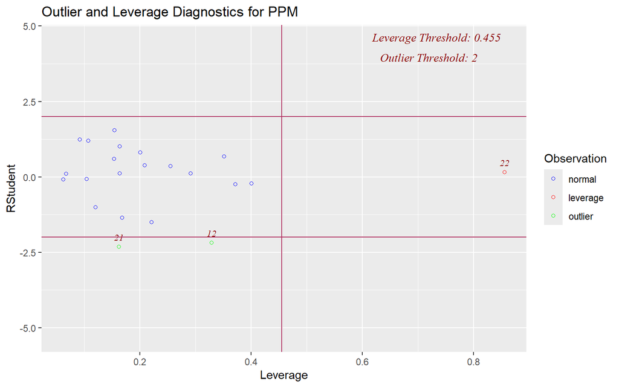

```r
ols_plot_resid_lev(model2)
```

Plot yang terbentuk dari fungsi `ols_plot_resid_lev()` menyatakan bahwa amatan ke-12 juga termasuk sebagai pencilan/outlier. Hal ini dikarenakan perbedaan rumusan yang dipakai pada `rstandard()` dan `rstudent()`. Jika diperhatikan dengan seksama, nilai rii menggunakan fungsi `rstandard()` pada amatan ke-12 mencapai nilai 1.96 yang memang dekat dengan 2 sehingga dapat dijadikan perhatian juga

## Amatan Berpengaruh

### Jarak Cook

```r
di <- cooks.distance(model2)
f <- qf(0.05,p,n-p, lower.tail = F)
data.frame(di, di>f)
```

```
##              di di...f
## 1  0.0011403008  FALSE
## 2  0.0337266923  FALSE
## 3  0.0001120994  FALSE
## 4  0.0001447618  FALSE
## 5  0.0001766921  FALSE
## 6  0.0705730111  FALSE
## 7  0.0082961823  FALSE
## 8  0.0804786488  FALSE
## 9  0.0275615771  FALSE
## 10 0.0069586555  FALSE
## 11 0.0302526055  FALSE
## 12 0.3828105120  FALSE
## 13 0.0133427061  FALSE
## 14 0.0341060299  FALSE
## 15 0.0005221758  FALSE
## 16 0.0404505599  FALSE
## 17 0.0071713916  FALSE
## 18 0.1178409150  FALSE
## 19 0.0089878643  FALSE
## 20 0.0509351724  FALSE
## 21 0.1647181301  FALSE
## 22 0.0326834768  FALSE
```

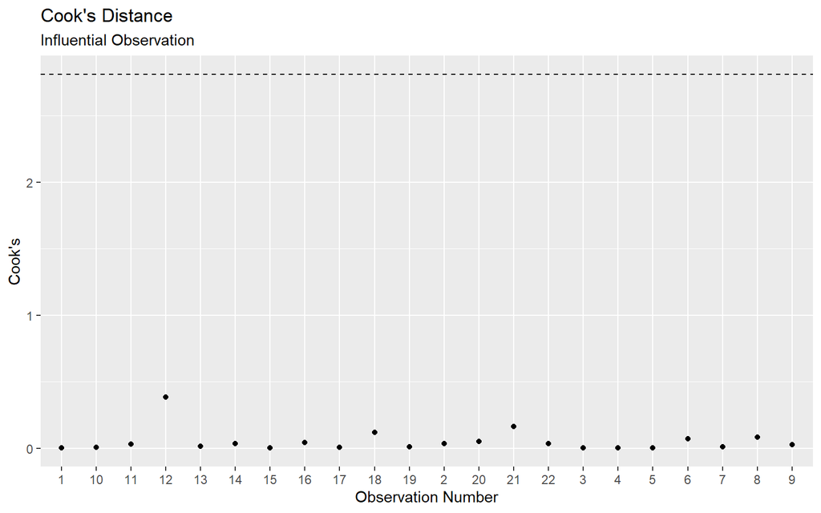

```r
cooks_crit = f
model_cooks <- cooks.distance(model2)
df <- data.frame(obs = names(model_cooks),
                 cooks = model_cooks)
ggplot(df, aes(y = cooks, x = obs)) +
  geom_point() +
  geom_hline(yintercept = cooks_crit, linetype="dashed") +
  labs(title = "Cook's Distance",
       subtitle = "Influential Observation ",
       x = "Observation Number",
       y = "Cook's")
```

Pemeriksaan amatan berpengaruh dengan jarak cook tidak dihasilkan nilai yang melebihi ambang batas

### DFBETAS

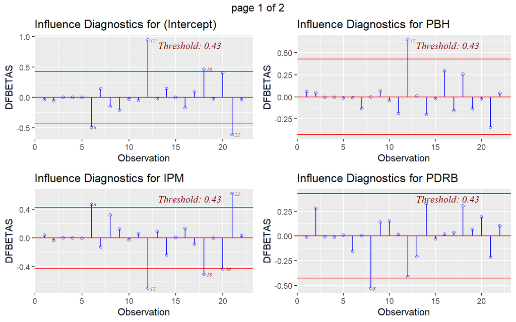

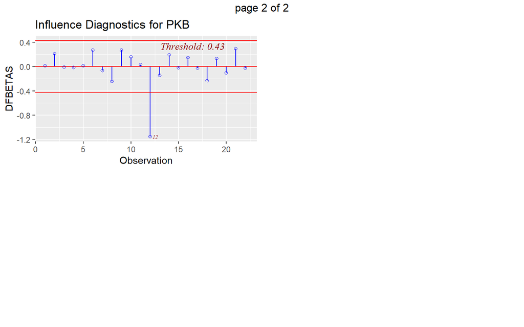

```r
ols_plot_dfbetas(model2)
```

Hasil DFBETAS akan menunjukkan pengaruh observasi terhadap setiap koefisien regresi, sehingga ada output untuk setiap parameter regresi. DFBETAS mengukur seberapa besar koefisien regresi berubah jika suatu observasi dihapus dari model.

### DFFITS

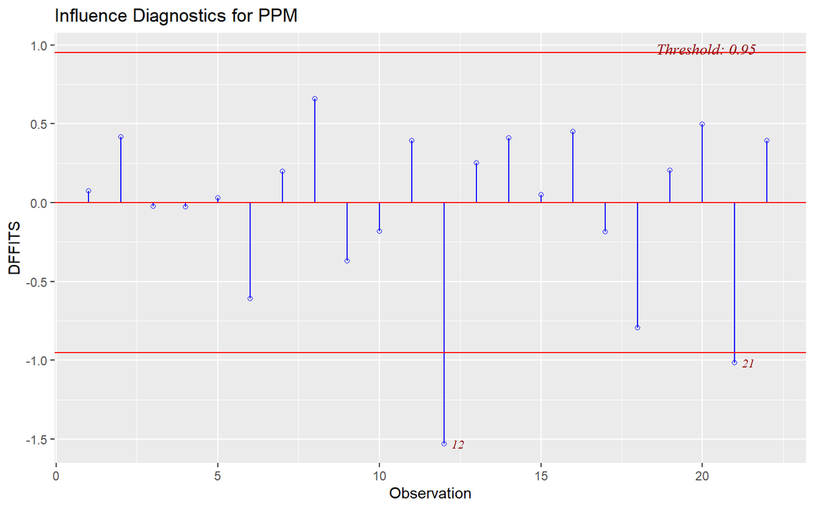

```r
ols_plot_dffits(model2)
```

Hasil DFFITS menunjukkan pengaruh observasi terhadap nilai prediksi Y, sehingga hanya menghasilkan satu output. DFFITS mengukur seberapa besar nilai prediksi $\hat{Y}_i$ berubah jika suatu observasi dihapus dari model, sehingga lebih tepat digunakan jika ingin melihat pengaruh observasi terhadap hasil model secara keseluruhan

```r
DFFITSi <- dffits(model2)

amatan_berpengaruh <- vector("list", dim(nilai)[1])
for (i in 1:dim(nilai)[1]) {
  cutoff <- 2 * sqrt((p / n))
  amatan_berpengaruh[[i]] <- which(abs(DFFITSi) > cutoff)
}
berpengaruh <- unlist(amatan_berpengaruh)
amatan_berpengaruh <- sort(unique(berpengaruh))
amatan_berpengaruh
```

```
## [1] 12 21
```

Amatan ke-12 dan 21 termasuk amatan berpengaruh sehingga sangat riskan jika disisihkan. Perlu ditelusuri lebih lanjut

# Pemodelan Penyisihan Amatan

```r
# gunakan peubah penjelas yang sudah diseleksi

dt1 <- dt %>% slice(-12)
model3 <- lm(PPM ~ IPM + PBH + PDRB + PKB, dt1)

dt2 <- dt %>% slice(-21)
model4 <- lm(PPM ~ IPM + PBH + PDRB + PKB, dt2)

dt3 <- dt %>% slice(-22)
model5 <- lm(PPM ~ IPM + PBH + PDRB + PKB, dt3)

dt4 <- dt %>% slice(-c(12, 21))
model6 <- lm(PPM ~ IPM + PBH + PDRB + PKB, dt4)

dt5 <- dt %>% slice(-c(12, 22))
model7 <- lm(PPM ~ IPM + PBH + PDRB + PKB, dt5)

dt6 <- dt %>% slice(-c(21, 22))
model8 <- lm(PPM ~ IPM + PBH + PDRB + PKB, dt6)

dt7 <- dt %>% slice(-c(12, 21, 22))
model9 <- lm(PPM ~ IPM + PBH + PDRB + PKB, dt7)
```

```r
get_metrics <- function(model) {
  adj_r2 <- summary(model)$adj.r.squared
  sse <- sum(model$residuals^2)
  return(c(adj_r2, sse))
}

model_metrics <- data.frame(
  Model = c("Model 2", "Model 3", "Model 4", "Model 5", "Model 6",
            "Model 7", "Model 8", "Model 9"),
  Adjusted_R2 = sapply(list(model2, model3, model4, model5,
                            model6, model7, model8, model9),
                       function(m) get_metrics(m)[1]),
  SSE = sapply(list(model2, model3, model4, model5,
                    model6, model7, model8, model9),
               function(m) get_metrics(m)[2])
)

print(model_metrics)
```

```
##     Model Adjusted_R2      SSE
## 1 Model 2   0.4138765 455.9213
## 2 Model 3   0.5033542 351.1692
## 3 Model 4   0.5361413 341.5554
## 4 Model 5   0.2970396 455.1798
## 5 Model 6   0.6025057 262.9080
## 6 Model 7   0.3898263 347.5751
## 7 Model 8   0.4337186 340.2260
## 8 Model 9   0.4958369 261.2673
```

```r
stargazer(model2, model4, model9, type = "text", font.size = "small",
          report = "vc*p")
```

```
##
## =====================================================================================
##                                            Dependent variable:
##                     -----------------------------------------------------------------
##                                                    PPM
##                              (1)                   (2)                   (3)
## -------------------------------------------------------------------------------------
## IPM                        -0.270                -0.614                -0.178
##                           p = 0.672             p = 0.305             p = 0.771
##
## PBH                         0.567                0.680*                 0.495
##                           p = 0.141             p = 0.057             p = 0.154
##
## PDRB                        0.001                0.001*                0.001*
##                           p = 0.165             p = 0.086             p = 0.060
##
## PKB                        0.340**               0.301**              0.444***
##                           p = 0.041             p = 0.045             p = 0.010
##
## Constant                    2.448                26.745                -13.457
##                           p = 0.957             p = 0.524             p = 0.767
##
## -------------------------------------------------------------------------------------
## Observations                 22                    21                    19
## R2                          0.526                 0.629                 0.608
## Adjusted R2                 0.414                 0.536                 0.496
## Residual Std. Error    5.179 (df = 17)       4.620 (df = 16)       4.320 (df = 14)
## F Statistic         4.707*** (df = 4; 17) 6.779*** (df = 4; 16) 5.426*** (df = 4; 14)
## =====================================================================================
## Note:                                                     *p<0.1; **p<0.05; ***p<0.01
```